# Lab 4: Avocado Prices

Author

Jasmine Cabrera

## 1. Getting Started

**Note:** Save both your .qmd file and your data set in the same folder within your STAT 331 directory.

## 2. Introduction & Set-up

In this lab we’re going to be looking at avocado prices. The dataset comes to us from Kaggle and represents weekly retail scan data.

**Note:** The data set website is an updated data set from the original published in 2018.

**Q0:** Create a Quarto file, load the data, and declare your package dependencies.

```r
library(tidyverse)
library(here)
library(RColorBrewer)
```

**Q1:** Briefly describe the data set. What information does it contain?

**A1:** The data represents the total consumption of Avocados from 2013 to 2018 in the United States. From the data set, we obtain information on the average price and quantity sold with US region, size of avocado, conventional or organic type, and date. The researchers assumed that the avocado consumption was a reason as to why younger people were not able to buy homes.

```r
avocado <- read_csv(here("data", "avocado.csv"))
```

**Q2:** Clean the data in any way you see fir.

**Note:** In particular, look carefully at the `region` variable. Notice that the category `"LosAngeles"` is contained in `"California"`, which is contained in `"West"`, which is contained in `"TotalUS"`. Think about how you want to handle this issue in your analysis.

How many distinct geographical regions are there? Can you categorize them into different types of geographical regions (e.g. major regions, metro regions, etc.)? Will you create a new variable for this? A new data set for each?

You may also want to consider renaming variables so they make sense intuitively. For example, what does 4046 mean in terms of the size of avocados?

```r
avocado <- avocado |>
    rename(small_Haas = "4046",
           large_Haas = "4225",
           xl_Haas = "4770",
           total_volume = "Total Volume")

unwanted <- tibble(region = c("California",
                              "Midsouth",
                              "GreatLakes",
                              "NorthernNewEngland",
                              "Plains",
                              "SouthCentral",
                              "SouthCarolina",
                              "TotalUS",
                              "Southeast"))

major_region <- tibble(region = c("Midwest",
                                  "South",
                                  "Northeast",
                                  "West"))

major_avo <- avocado |>
  semi_join(major_region, by = "region")

metro_avo <- avocado |>
  anti_join(unwanted, by = "region") |>
  anti_join(major_region, by = "region")
```

## 3. Summarizing Avocado Sales

**Note:** Use your cleaned data set to answer these next three questions. In other words, `avocado_clean` is your starting “main subject” for each of question.

**Q3:** Which major region sold the most organic, small Haas avocados in 2017?

**A3:** The West Region is the region that sold the most organic, small Haas avocados in 2017 with 1,870,206 avocados sold.

```r
major_avo |>
  filter(year == 2017,
         type == "organic") |>
  group_by(region) |>
  summarize(region_sum = sum(small_Haas)) |>
  slice_max(region)
```

```
# A tibble: 1 × 2
  region region_sum
  <chr>       <dbl>
1 West     1870206.
```

**Q4:** Use the `separate()` function to split the `Date` variable into year, month, and day. In which month is the highest volume of avocado sales?

**A4:** The month with the highest volume of avocado sales is January with 205,987,434 avocados sold. February, however, has the highest average volume of avocado sales with on average 3,178,558 being sold.

```r
major_avo |>
  separate(col = Date,
           into = c("Year",
                    "Month",
                    "Day"),
           sep = "-") |>
  group_by(Month) |>
  summarize(month_volume = sum(total_volume),
            month_avg_vol = mean(total_volume)) |>
  slice_max(month_avg_vol)
```

```
# A tibble: 1 × 3
  Month month_volume month_avg_vol
  <chr>        <dbl>         <dbl>
1 02      203427698.      3178558.
```

**Q5:** Which metro area regions sold the most total avocados? Plot side-by-side box plots of total volume for only the five regions with the highest averages for the `Total Volume` variable.

**A5:** Los Angeles was the metro area region that sold the most total avocados at a total volume of 507,896,548. From the side-by-side box plots we can also see that Los Angeles had the highest in mean total volume as well.

**Sources:**

https://statisticsglobe.com/scale-colour-fill-brewer-rcolorbrewer-package-r

**Note:** You still want each individual observations in your plot, but you will need to somehow identify the average for each metro geographical region.

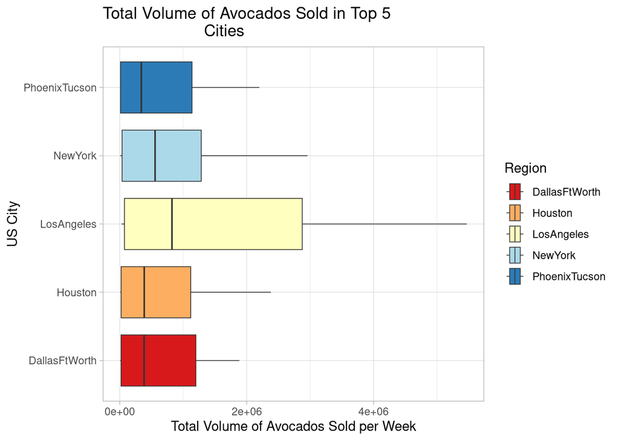

```r
metro_total <- metro_avo |>
  select(total_volume, region) |>
  group_by(region) |>
  summarize(month_volume = sum(total_volume),
            month_avg_vol = mean(total_volume)) |>
  slice_max(month_avg_vol, n = 5)

bigfive <- metro_avo |>
  semi_join(metro_total,
            by = "region")

ggplot(data = bigfive,
       mapping = aes(x = total_volume,
                     y = region,
                     fill = region)) +
  geom_boxplot(size = 0.3) +
  labs(x = "Total Volume of Avocados Sold per Week",
       y = "US City",
       title = "Total Volume of Avocados Sold in Top 5
                      Cities",
       fill = "Region") +
  theme(plot.title = element_text(face = "bold",
                                  size = 13),
        axis.title = element_text(size = 10,
                                  face = "bold"),
        axis.text = element_text(size = 8),
        legend.position = "none") +
  theme_light() +
  scale_fill_brewer(palette = "RdYlBu")
```

## 4. Reshaping

The following four California regions are in this data set: `"LosAngeles"`, `"SanDiego"`, `"Sacramento"`, and `"SanFrancisco"`. Answer the following questions about these California regions **only**.

**Q6:** In which regions is the price of organic versus conventional avocados most different? Support your answer with a few summary statistics and a visualization.

**A6:** San Francisco is the region where the price of organic versus conventional avocados are the most different. In the bar plot constructed below, each city in California and its average price for organic and conventional avocados is displayed. San Francisco has an average price of $1.40 for conventional avocados compared to the average price of $2.20 for organic avocados.

**Note:** You do not have to, but you may want to transform your data. Sketch out what you want the data set to look like before you begin to code! Come up with a game plan to answer this question.

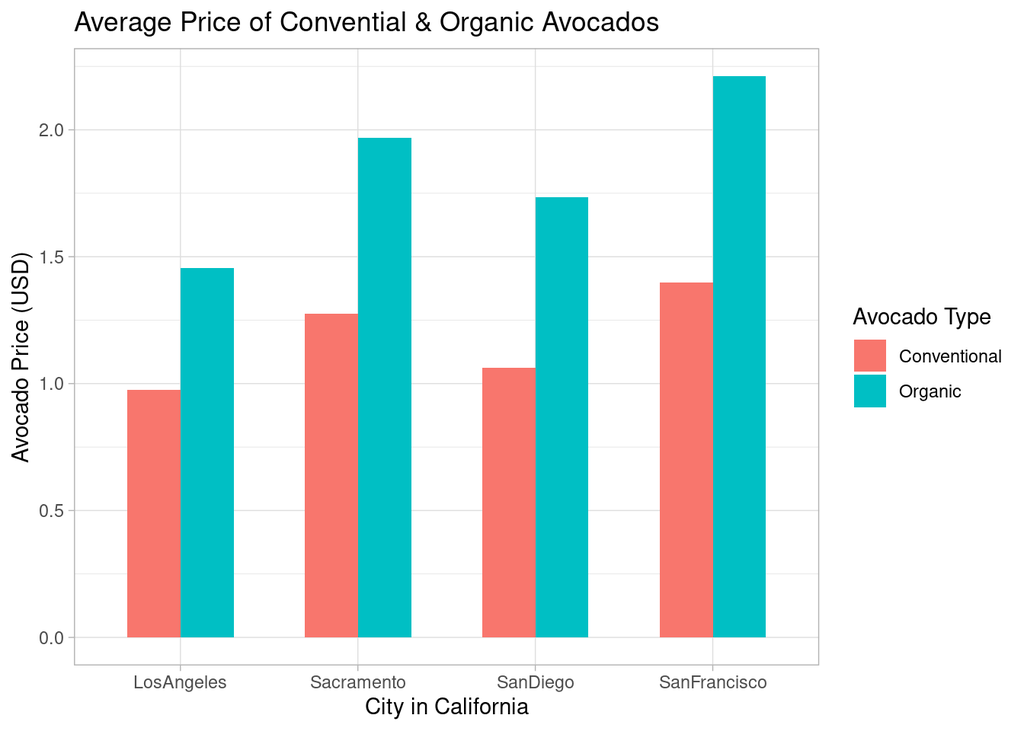

```r
cal_avos <- metro_avo |>
  filter(region %in% c("LosAngeles",
                       "SanDiego",
                       "Sacramento",
                       "SanFrancisco")) |>
  select(Date, type, region, AveragePrice) |>
  pivot_wider(names_from = type,
              values_from = AveragePrice) |>
  group_by(region) |>
  summarize(avg_conventional = mean(conventional),
            avg_organic = mean(organic))

cal_avos |>
  pivot_longer(avg_conventional : avg_organic,
               names_to = "type",
               values_to = "price") |>
  ggplot(mapping = aes(x = region,
                       y = price,
                       fill = type)) +
  geom_bar(stat = "identity",
           position = position_dodge(),
           width = 0.6) +
  labs(x = "City in California",
       y = "Avocado Price (USD)",
       title = "Average Price of Convential & Organic Avocados",
       fill = "Avocado Type") +
  theme(plot.title = element_text(face = "bold",
                                 size = 15),
       axis.title = element_text(size = 10,
                                 face = "bold"),
       axis.text = element_text(size = 8),
       legend.title = element_text(size = 10,
                                   face = "bold"),
       legend.text = element_text(size = 8),
       legend.key.size = unit(.5, "cm")) +
  scale_fill_discrete(labels = c("Conventional", "Organic")) +
  theme_light()
```

**Q7:** The following plot shows, for all four California regions, the proportion of the mean Haas avocado sales that are small, large, or extra large; conventional vs. organic. Recreate the plot.

**Note:** This will require restructuring of your data! Sketch out what you want the data set to look like before you begin to code! I recommend starting with your California data set you create in Q6.

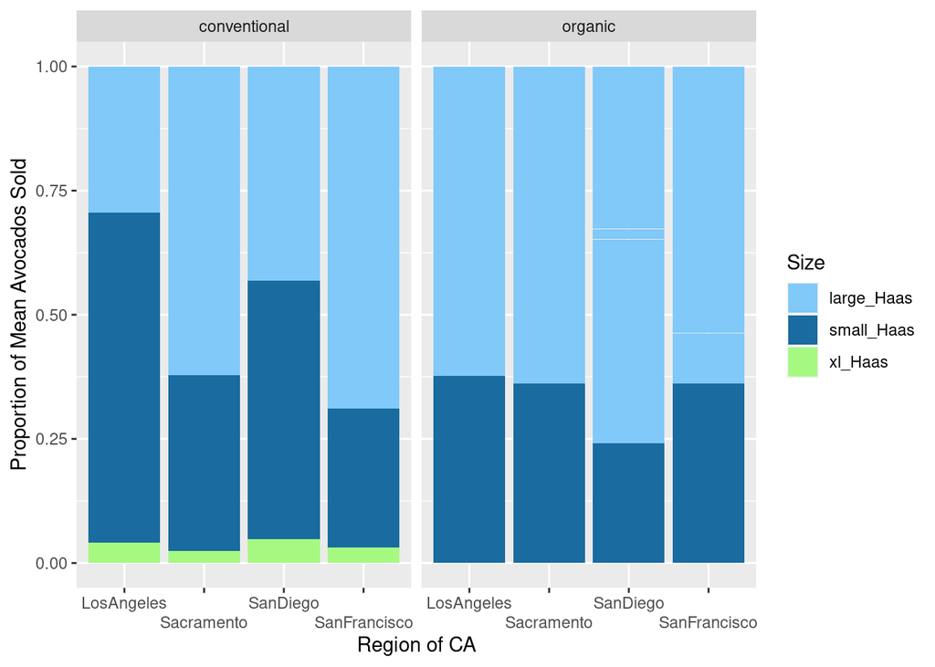

```r
colors <- c("#80C9F9", "#196BA0", "#A5F980")

metro_avo |>
  filter(region %in% c("LosAngeles",
                       "SanDiego",
                       "Sacramento",
                       "SanFrancisco")) |>
  select(small_Haas : xl_Haas, type, region) |>
  pivot_longer(small_Haas : xl_Haas,
               names_to = "Size",
               values_to = "Quantity") |>
  ggplot(mapping = aes(x = region,
                       y = Quantity,
                       fill = Size)) +
  geom_col(position = "fill") +
  labs(x = "Region of CA",
       y = "Proportion of Mean Avocados Sold") +
  facet_grid(~ type) +
  scale_x_discrete(guide = guide_axis(n.dodge = 2)) +
  scale_fill_manual(values = colors)
```